# Midterm Report

2025-03-13

Source on Github: https://github.com/TJ838/JSC370_Midterm

# Introduction

Economic development and public health are closely intertwined, with economic stability often influencing health outcomes. Countries with strong economies tend to have better healthcare infrastructure, higher public health expenditures, and improved living conditions. On the other hand, economic instability can lead to reduced access to healthcare, malnutrition, and increased disease burden.

This study seeks to explore the relationship between economic indicators (Gross Domestic Product (GDP), unemployment rates, and inflation) and key health indicators (life expectancy, mortality rates, immunization rates, access to clean water, and sanitation) of countries in the world. The central research question is: How do economic conditions influence health outcomes globally over time?

The hypothesis is that:

1. Countries with higher GDP will have higher life expectancy and lower mortality rates, as economic prosperity enables better healthcare systems.
2. Higher unemployment rates will correlate with poorer health outcomes, as job insecurity often leads to lower income and limited access to healthcare services.
3. Higher inflation rates may negatively impact health indicators by increasing the cost of healthcare and essential goods, reducing affordability for lower-income populations.

The results will be significant as understanding these relationships can help policymakers and international organizations make informed decisions about resource allocation, social welfare policies, and healthcare investments.

# Methods

## Data acquisition

The dataset for this study was collected using the World Bank API. This API provides access to high-quality, globally comparable economic and health statistics. The selected indicators cover a period from 1960 to 2023 for all available countries. The date range was picked in order to include as much observations as possible.

In order to showcase the ability to use different techniques of gathering data, I used the wbstats package in R to gather the data for the health indicators, and used httr package and the API call method to gather the data for the economic indicators (using url http://api.worldbank.org/v2). The source of data for both methods were essentially the same.

The following five health indicators were extracted, with their individual indicator codes provided, as needed for the API call:

Life Expectancy (SP.DYN.LE00.IN): The average number of years a newborn is expected to live.

Mortality Rate (SH.DYN.MORT): The number of deaths per 1,000 live births.

Immunization Rate (SH.IMM.IDPT): The percentage of infants receiving standard immunizations. Water Access (SH.H2O.SAFE.ZS): The percentage of the population with access to safe drinking water.

Sanitation Access (SN.ITK.DEFC.ZS): The percentage of the population with access to improved sanitation facilities.

Additionally, three economic indicators were obtained:

Gross Domestic Product (GDP) (NY.GDP.MKTP.CD): The total economic output of a country in current USD.

Unemployment Rate (SL.UEM.TOTL.ZS): The percentage of the labor force that is unemployed.

Inflation Rate (FP.CPI.TOTL.ZG): The annual percentage change in consumer prices.

## Tools used

Data Extraction: wbstats (World Bank API), httr

Data Cleaning: dplyr, tidyr

Data Visualization: ggplot2 for plots and visualizations

Summary Tables: kableExtra for well-formatted tables in RMarkdown

# Preliminary Results

## Summary statistics

The following tables summarized the descriptions of key economic and health indicators across countries and years:

Table 1: Health Indicators and Their Descriptions

| Indicator | Description |
| --- | --- |
| Life Expectancy | Average number of years a newborn is expected to live. |
| Mortality Rate | Under-5 mortality rate per 1,000 live births. |
| Immunization Rate | Percentage of children immunized with DTP. |
| Water Access | Percentage of the population with access to safe water. |
| Sanitation Access | Percentage of the population with access to sanitation facilities. |

Table 2: Economic Indicators and Their Descriptions

| Indicator | Description |
| --- | --- |
| GDP | Gross Domestic Product (current US$). |
| Unemployment Rate | Percentage of the labor force that is unemployed. |
| Inflation Rate | Annual percentage change in consumer prices. |

The following tables statistically summarized of key economic and health indicators across countries and years:

Table 3: Summary Statistics of Health Indicators

|  | Life Expectancy | Mortality Rate (Under 5) | Immunization Rate (DTP) | Access to Water (%) | Access to Sanitation (%) |
| --- | --- | --- | --- | --- | --- |
|  | Min. :11.99 | Min. : 1.50 | Min. : 0.00 | Min. : 18.68 | Min. : 2.794 |
|  | 1st Qu.:57.03 | 1st Qu.: 17.00 | 1st Qu.:69.57 | 1st Qu.: 78.66 | 1st Qu.: 49.537 |
|  | Median :66.96 | Median : 43.00 | Median :87.00 | Median : 93.47 | Median : 85.375 |
|  | Mean :64.39 | Mean : 71.27 | Mean :78.44 | Mean : 85.57 | Mean : 72.751 |
|  | 3rd Qu.:72.65 | 3rd Qu.:102.03 | 3rd Qu.:95.00 | 3rd Qu.: 98.95 | 3rd Qu.: 97.437 |
|  | Max. :85.53 | Max. :428.70 | Max. :99.00 | Max. :100.00 | Max. :100.000 |

Table 4: Summary Statistics of Economic Indicators

|  | GDP (Current US$) | Unemployment Rate (%) | Inflation Rate (%) |
| --- | --- | --- | --- |
|  | Min. :2.586e+06 | Min. : 0.100 | Min. : -17.640 |
|  | 1st Qu.:2.294e+09 | 1st Qu.: 4.083 | 1st Qu.: 2.409 |
|  | Median :1.692e+10 | Median : 6.341 | Median : 4.944 |
|  | Mean :1.185e+12 | Mean : 7.898 | Mean : 19.826 |
|  | 3rd Qu.:2.013e+11 | 3rd Qu.:10.390 | 3rd Qu.: 9.702 |
|  | Max. :1.062e+14 | Max. :38.800 | Max. :23773.132 |

## Visualizations

It is important to note that, the economic indicators such as GDP tend to have highly skewed distributions, meaning that a few extremely large values dominate the dataset. This creates problems when analyzing relationships between variables, as a small number of high-GDP countries can distort trends, making it difficult to see meaningful patterns. Therefore, I log transformed the economic indicators for better visualization.

Here are the distributions of the three economic indicators across all countries from 1960 to 2023:

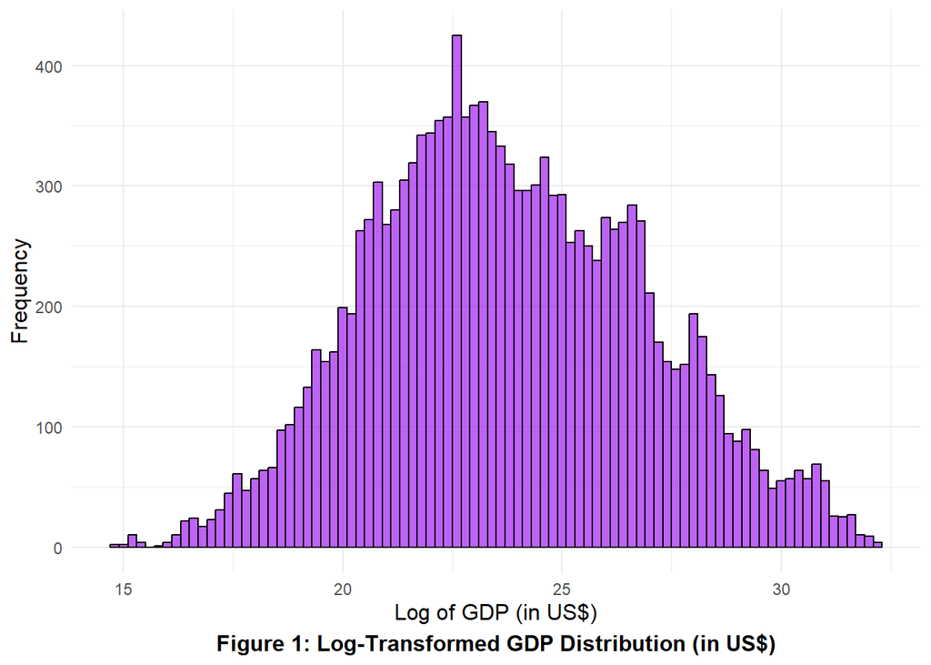

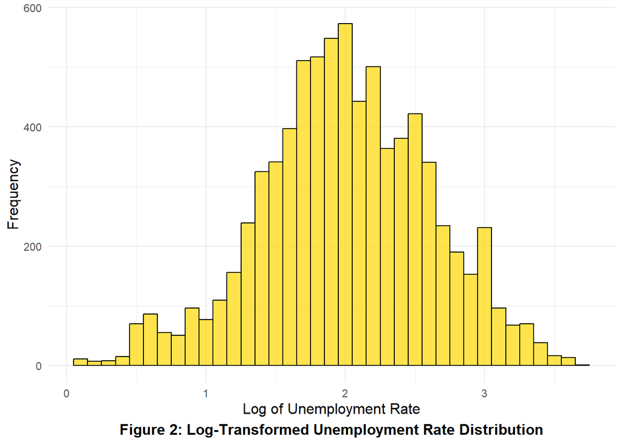

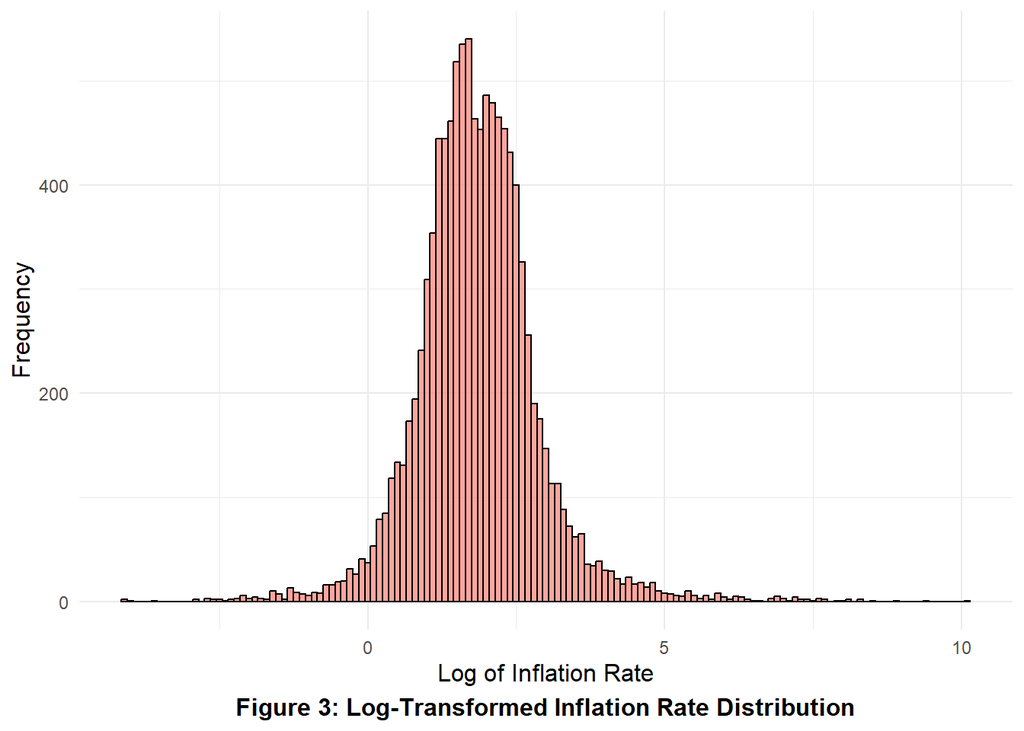

Here are the distributions of the five health indicators across all countries from 1960 to 2023:

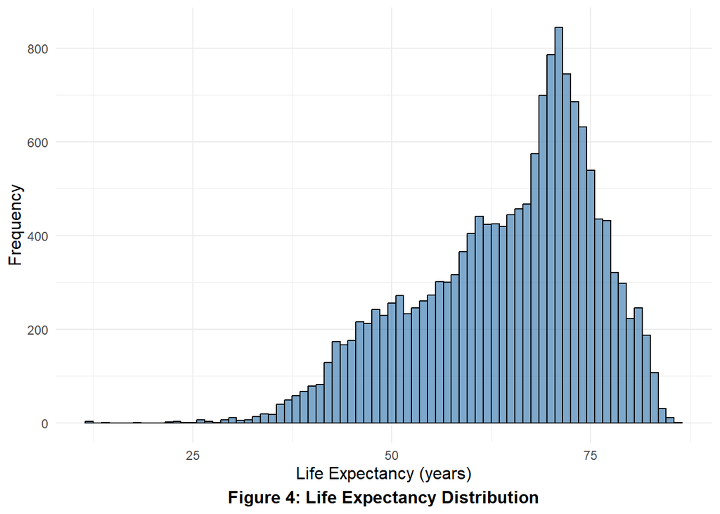

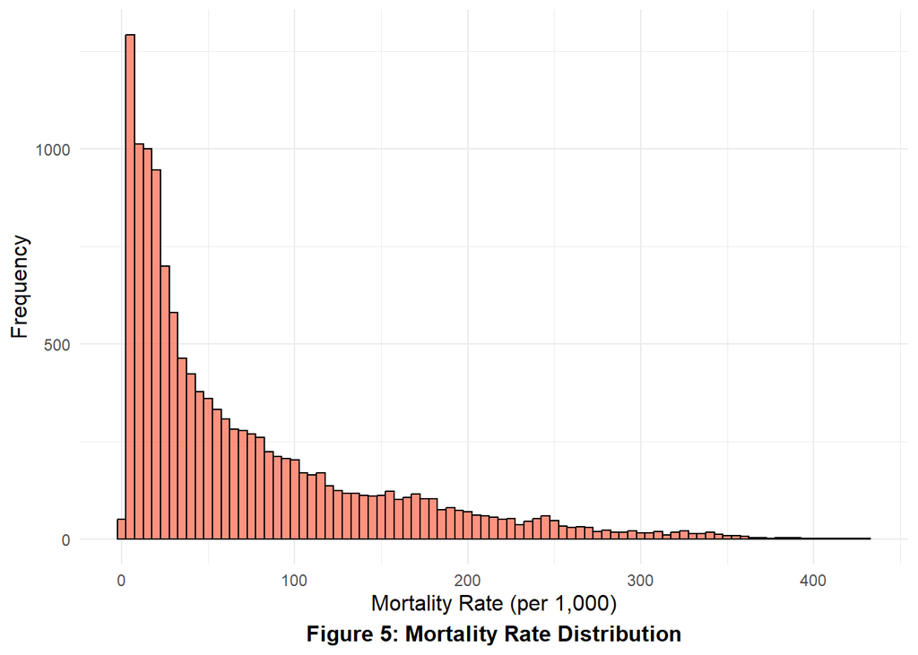

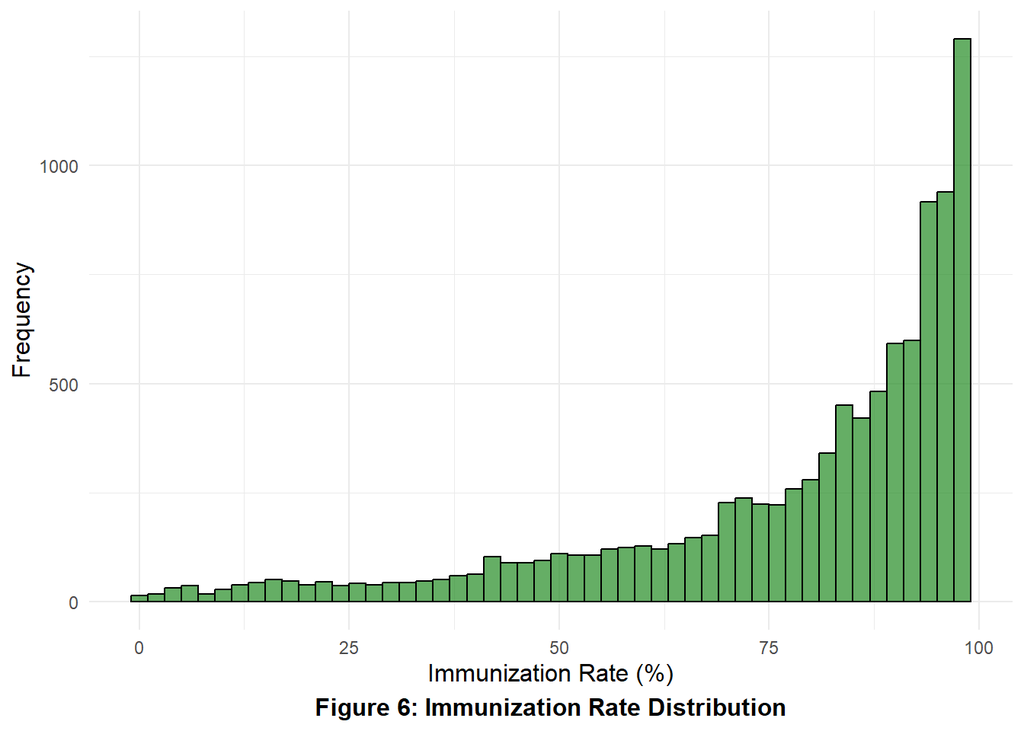

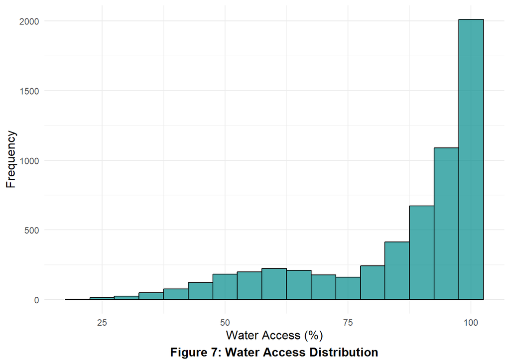

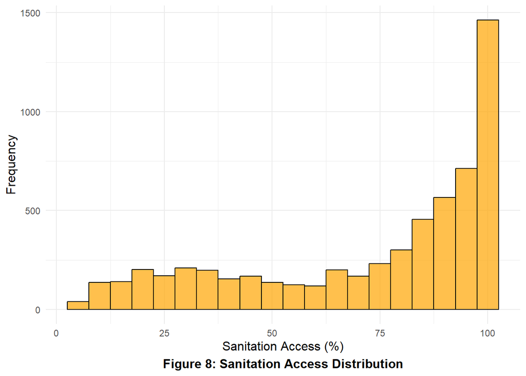

Here are the scatterplots of the three economic indicators with five health indicators across all countries from 1960 to 2023. As there were a total of 15 combinations, I only picked a few combinations that are relatively meaningful to display:

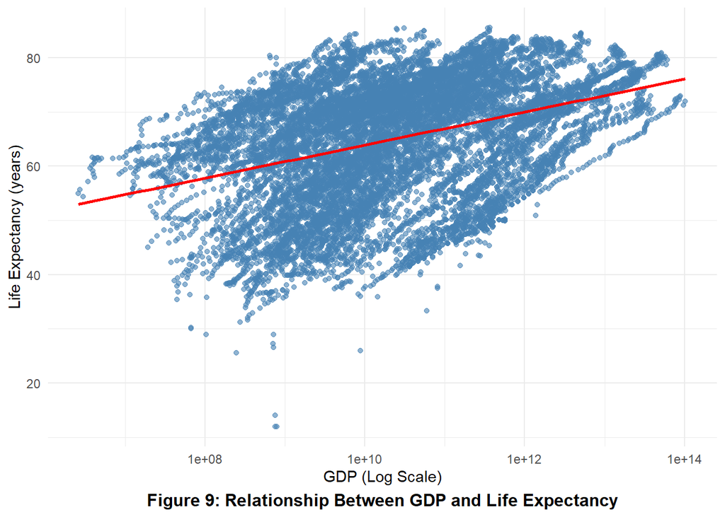

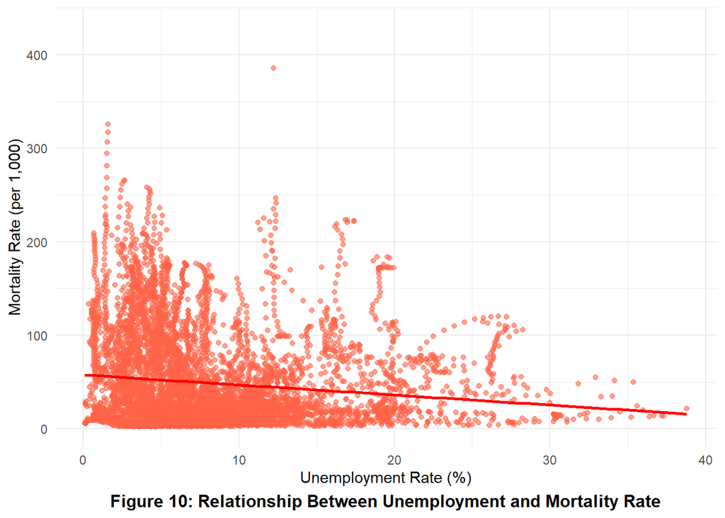

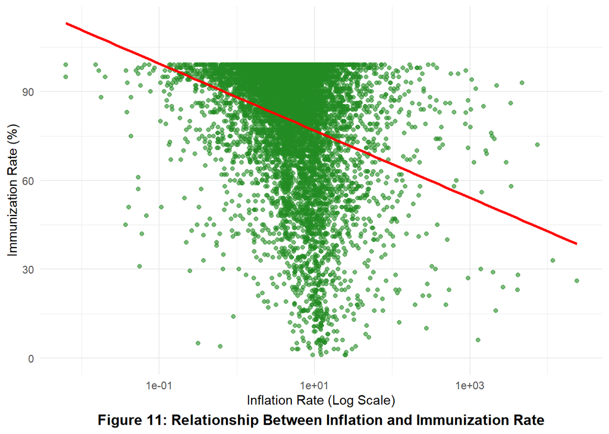

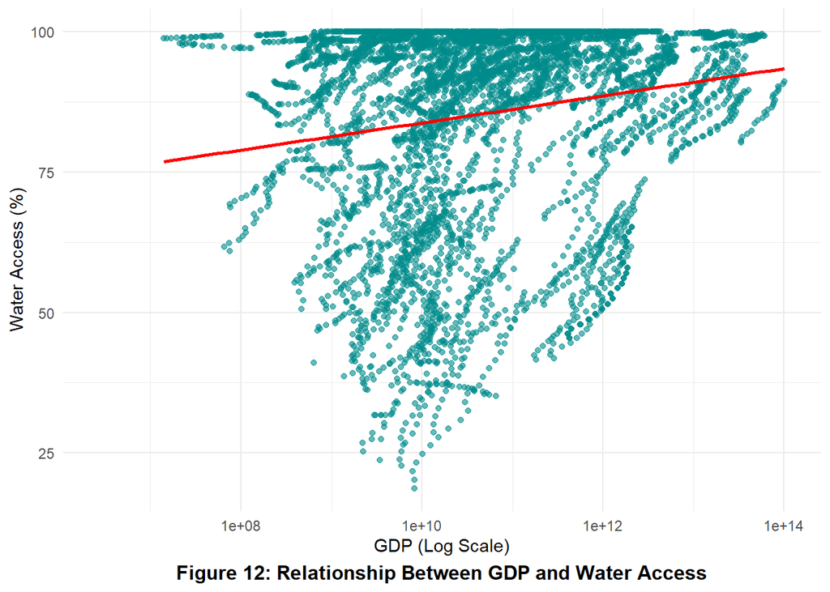

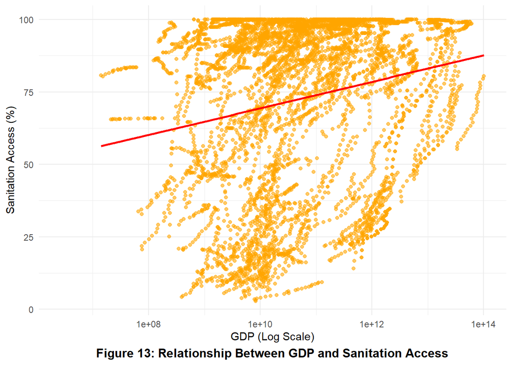

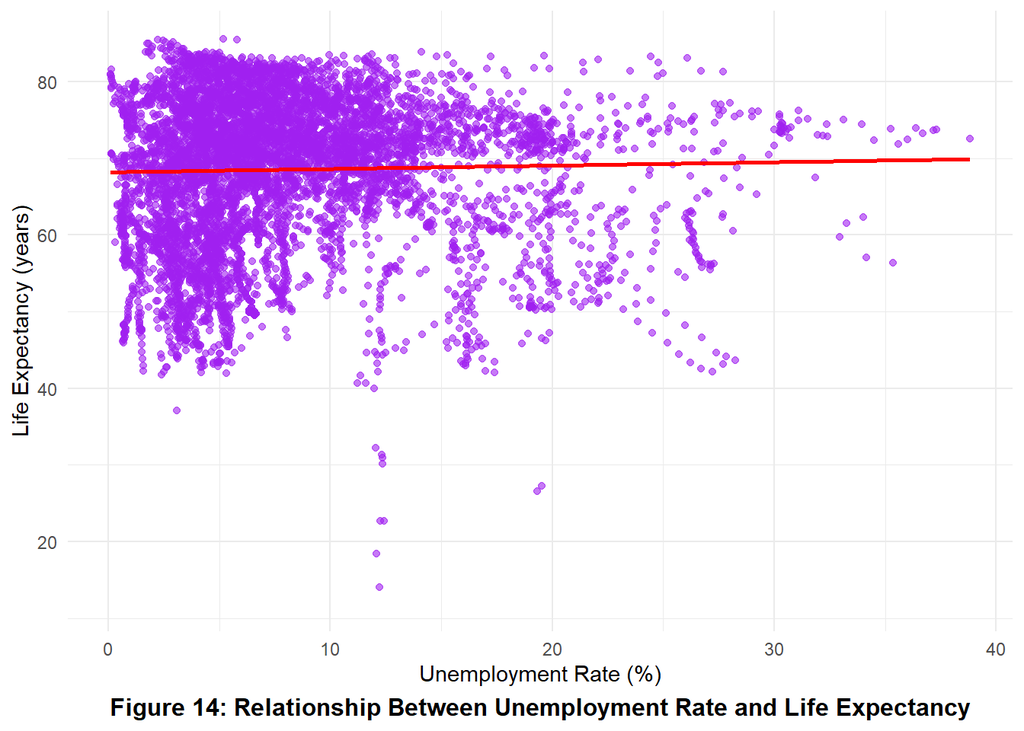

# Summary

## Health Indicators

Life Expectancy ranges from 11.99 to 85.53 years, with a median of 66.96 years. The distribution appears left-skewed, although the mean (64.39) is slightly lower than the median, suggesting that some countries have significantly lower life expectancy values.

Mortality Rate (Under 5) has a wide spread, ranging from 1.50 to 428.70 deaths per 1,000 live births. The median (43.00) and mean (71.27) suggest a right-skewed distribution, likely influenced by countries with very high child mortality.

Immunization Rate (DTP) is skewed to the left, with most countries having high coverage. The minimum value is 0%, while the maximum is 99%. The median (87%) and third quartile (95%) indicate that many countries achieve high immunization rates.

Access to Water and Sanitation is generally high across countries, with both variables showing median values of 93.47% and 85.38%, respectively. However, the first quartiles (78.66% for water and 49.54% for sanitation) suggest that a significant number of countries still experience lower access, leading to a left-skewed distribution for these variables.

## Economic Indicators:

GDP (Current US$) shows an extreme right-skew, with values ranging from $2.6 million to $106.2 trillion. The median GDP is $16.9 billion, while the mean is $1.185 trillion, highlighting the presence of a few very wealthy countries driving up the average. Log transformation could be necessary to normalize the distribution. After normalizing, the distribution appears moderately spread.

Unemployment Rate (%) is moderately spread, ranging from 0.1% to 38.8%, with a median of 6.34%. The distribution is slightly right-skewed, meaning a few countries have significantly higher unemployment rates.

Inflation Rate (%) exhibits high variability, with a minimum of -17.64% (deflation) and a maximum of 23,773% (hyperinflation). The median of 4.94% suggests that most countries experience moderate inflation, but extreme outliers result in a highly right-skewed distribution, further justifying the use of log transformation, after which we get a relatively moderate skewness.

## Relationships between Health Indicators and Economic Indicators:

Higher unemployment rates were associated with lower child mortality rates. This suggests that our hypothesis that job insecurity and economic instability may reduce access to healthcare, leading to higher child mortality, could be wrong.

After log-transforming inflation, we observed a noticeable negative correlation with immunization rates. Countries experiencing hyperinflation tend to have lower immunization rates, likely due to economic instability disrupting public health programs.

Countries with higher GDP and lower unemployment rates generally have better access to clean water and sanitation.

However, there is possibility that some resource-rich developing nations show high GDP but low access rates, which requires further investigation into the dataset. We cannot yet conclude that wealth alone does guarantee public health infrastructure improvements.

There does not seem to be a noticeable corelation between unemployment rate and life expectancy, indicating that unemployment rate is not a primary or determining factor influencing life expectancy. Further investigation into other variables and a deeper analysis may be needed to understand the true drivers of life expectancy across different populations.

# Future plans for final analysis

1. Further explore the strength and direction of relationships between economic and health indicators by checking for multicollinearity to ensure robust regression analysis.
2. Use multivariate regression to quantify the impact of GDP, inflation, and unemployment on health outcomes. It can be meaningful if potential confounders such as education levels, government health expenditure, and regional differences are controlled.
3. Compare trends in developed vs. developing regions by categorizing countries by income level (low, middle, high) to assess whether the relationships vary across different economic tiers.
4. Investigate how economic downturns in history such as the COVID pandemic affected health outcomes and specific patterns in the data.